# STA130H1 – Fall 2018

Week 1 Practice Problems

N. Moon and N. Taback

# Instructions

## What should I bring to tutorial on January 12?

- R output (e.g., plots) for Question 2. You can either bring a hardcopy or bring your laptop with the output.

## First steps to answering these questions.

- Login to RStudio https://rstudio.chass.utoronto.ca/
- Download this R Notebook directly into RStudio by typing the following code into the RStudio console window.

```r
file_url <- "https://raw.githubusercontent.com/ntaback/UofT_STA130/master/week1/Week1PracticeProblems-student.Rmd"
download.file(url = file_url , destfile = "Week1PracticeProblems-student.Rmd")
```

Look for the file “Week1PracticeProblems-student.Rmd” under the Files tab then click on it to open.

- Change the subtitle to “Week 1 Practice Problems Solutions” and change the author to your name and student number.
- Type your answers below each question. Remember that [R code chunks](http://rmarkdown.rstudio.com/authoring_rcodechunks.html) can be inserted directly into the notebook by choosing Insert R from the Insert menu (see Using [R Markdown for Class Assignments](https://ntaback.github.io/UofT_STA130/Rmarkdownforclassreports.html)). In addition this R Markdown [cheatsheet](http://www.rstudio.com/wp-content/uploads/2016/03/rmarkdown-cheatsheet-2.0.pdf), and [reference](http://www.rstudio.com/wp-content/uploads/2015/03/rmarkdown-reference.pdf) are great resources as you get started with R Markdown.
- If you are NOT working on https://rstudio.chass.utoronto.ca/ then you will need to install several libraries such as `tidyverse`, `mdsr` and `mosaic` to complete the questions.

# Practice Problems

## Question 1

The `marriage` data is in the `mosaic` package, which you must first load with the command `library(mosaic)`. You can read more about the data and the variables here: https://rdrr.io/cran/mosaicData/man/Marriage.html.

1. Construct at least two plots that each show the distribution of one categorical variable.
2. Construct at least two plots that each show the distribution of one quantitative variable.
3. Construct a plot that shows the relationship between two variables. What can you say about the relationship?

## Question 2

The `Gestation` data set is also part of the `mosaic` package.

1. Create a histogram and boxplot of the length of gestation. What is the shape of the distribution? Explain.
2. Do highly college educated mother’s have different gestation times compared to mother’s that did not graduate high school? Construct a data vizualization to investigate the answer to this question. Explain why you chose this vizualization.
3. Does smoking lead to shorter gestation times? Construct a data vizualization to investigate the answer to this question. Explain why you chose this vizualization.
4. Approximately twenty-five percent of mother’s that never smoked had a gestation time less than ______? Explain how you derived your estimate.

```r
library(mosaic)
library(tidyverse)
glimpse(Gestation)
```

```
## Observations: 1,236
## Variables: 23
## $ id        <int> 15, 20, 58, 61, 72, 100, 102, 129, 142, 148, 164, 17...
## $ pluralty  <int> 5, 5, 5, 5, 5, 5, 5, 5, 5, 5, 5, 5, 5, 5, 5, 5, 5, 5...
## $ outcome   <int> 1, 1, 1, 1, 1, 1, 1, 1, 1, 1, 1, 1, 1, 1, 1, 1, 1, 1...
## $ date      <int> 1411, 1499, 1576, 1504, 1425, 1673, 1449, 1562, 1408...
## $ gestation <int> 284, 282, 279, NA, 282, 286, 244, 245, 289, 299, 351...
## $ sex       <int> 1, 1, 1, 1, 1, 1, 1, 1, 1, 1, 1, 1, 1, 1, 1, 1, 1, 1...
## $ wt        <int> 120, 113, 128, 123, 108, 136, 138, 132, 120, 143, 14...
## $ parity    <int> 1, 2, 1, 2, 1, 4, 4, 2, 3, 3, 2, 4, 3, 5, 3, 4, 3, 3...
## $ race      <int> 8, 0, 0, 0, 0, 0, 7, 7, 0, 0, 0, 0, 0, 8, 7, 7, 4, 3...
## $ age       <int> 27, 33, 28, 36, 23, 25, 33, 23, 25, 30, 27, 32, 23, ...
## $ ed        <int> 5, 5, 2, 5, 5, 2, 2, 1, 4, 5, 5, 2, 1, 5, 2, 2, 7, 2...
## $ ht        <int> 62, 64, 64, 69, 67, 62, 62, 65, 62, 66, 68, 64, 63, ...
## $ wt.1      <int> 100, 135, 115, 190, 125, 93, 178, 140, 125, 136, 120...
## $ drace     <fct> 8, 0, 5, 3, 0, 3, 7, 7, 3, 0, 5, 0, 5, 0, 7, 7, 7, 3...
## $ dage      <int> 31, 38, 32, 43, 24, 28, 37, 23, 26, 34, 28, 36, 28, ...
## $ ded       <int> 5, 5, 1, 4, 5, 2, 4, 4, 1, 5, 4, 1, 2, 5, 0, 0, 1, 2...
## $ dht       <int> 65, 70, NA, 68, NA, 64, NA, 71, 70, NA, NA, 74, NA, ...
## $ dwt       <int> 110, 148, NA, 197, NA, 130, NA, 192, 180, NA, NA, 18...
## $ marital   <int> 1, 1, 1, 1, 1, 1, 1, 1, 0, 1, 1, 1, 1, 1, 1, 1, 1, 1...
## $ inc       <int> 1, 4, 2, 8, 1, 4, NA, 2, 2, 2, NA, 2, 2, 2, 1, 1, 1,...
## $ smoke     <int> 0, 0, 1, 3, 1, 2, 0, 0, 0, 1, 3, 1, 1, 1, 0, 0, 1, 1...
## $ time      <int> 0, 0, 1, 5, 1, 2, 0, 0, 0, 1, 4, 1, 1, 1, 0, 0, 1, 1...
## $ number    <int> 0, 0, 1, 5, 5, 2, 0, 0, 0, 4, 2, 1, 1, 2, 0, 0, 5, 5...
```

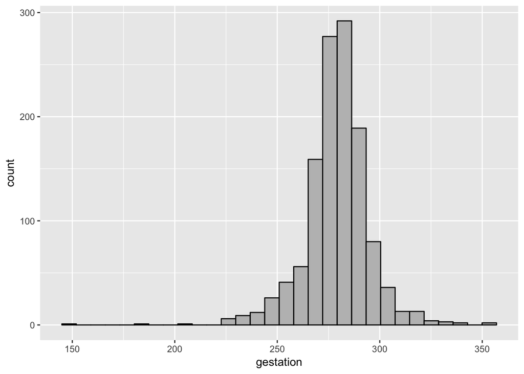

```r
ggplot(data = Gestation) +
  aes(x = gestation) +
  geom_histogram(colour = "black", fill = "grey")
```

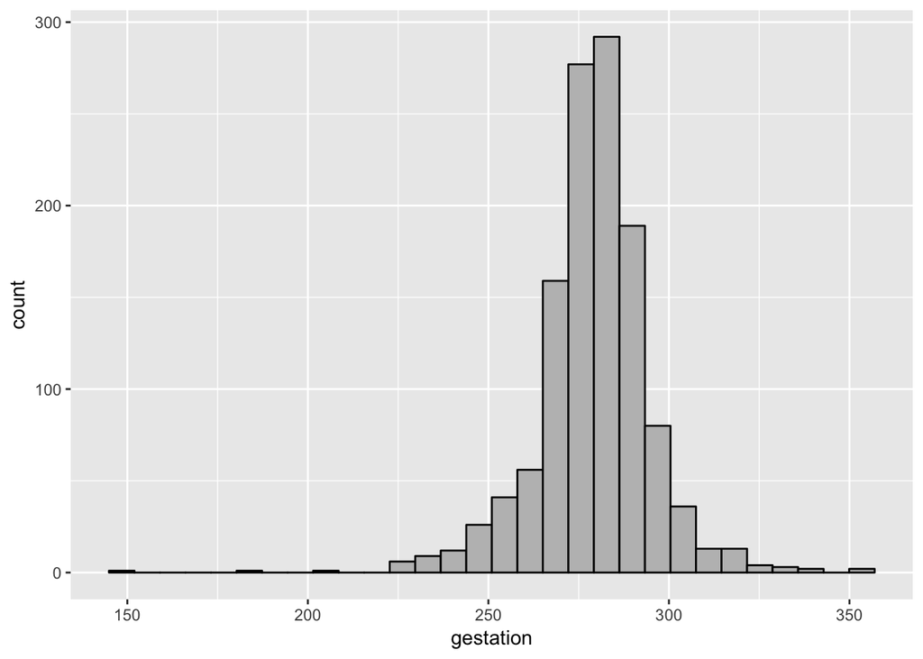

```r
ggplot(data = Gestation) +
  aes(x = gestation) +
  geom_histogram(colour = "black", fill = "grey")
```

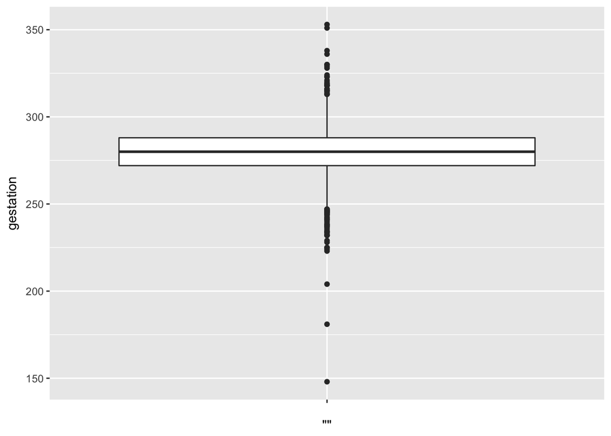

```r
ggplot(data = Gestation) +
  aes(y = gestation, x = "") +
  geom_boxplot()
```

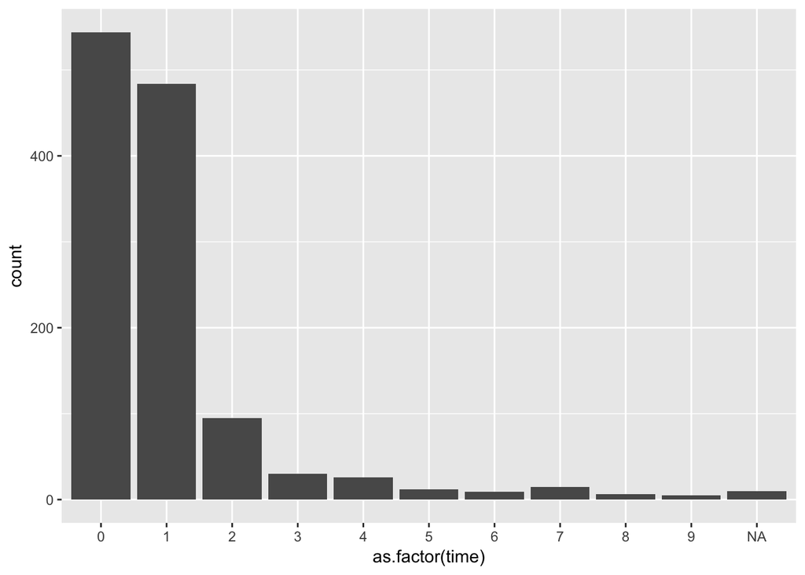

```r
ggplot(data = Gestation) +
  aes(x = as.factor(time)) +
  geom_bar()
```

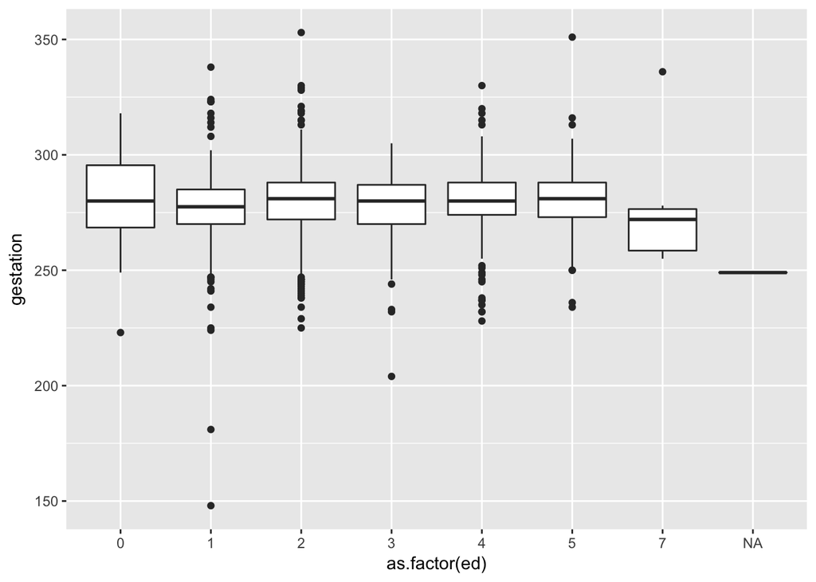

```r
ggplot(data = Gestation) +
  aes(y = gestation, x = as.factor(ed)) +
  geom_boxplot()
```

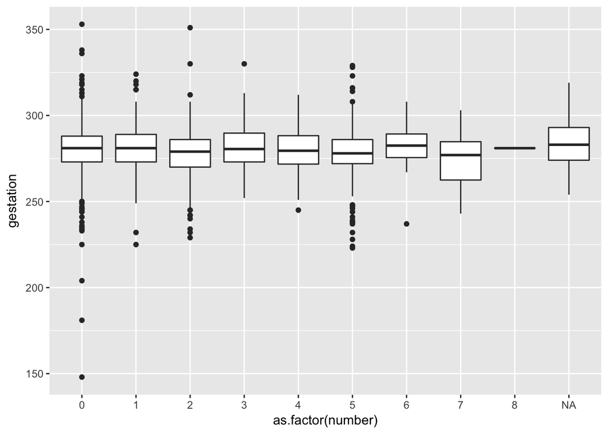

```r
ggplot(data = Gestation) +
  aes(y = gestation, x = as.factor(number)) +
  geom_boxplot()
```

## Question 3

For this exercise, you will load data from an external source. You can read about the data here: http://sta220.utstat.utoronto.ca/data/the-skeleton-data/.

The data are in a plain text file with spaces between columns here: http://stats.onlinelearning.utoronto.ca/wp-content/uploaded/Data/SkeletonDatacomplete.txt. The following code will load the data into a tibble (the tidyverse version of a data frame).

1. Read the data into `R` using the following code.

```r
library(tidyverse)
data_url <- "http://stats.onlinelearning.utoronto.ca/wp-content/uploaded/Data/SkeletonDatacomplete.txt"
skeleton_data <- read_table(data_url)
```

Inspect the data to make sure it is read in completely. You can compare by going directly to the `data_url`.

2. Construct at least four interesting graphs with the data, including: a graph of one categorical variable, a graph of one quantitative variable, a graph with at least two variables, a graph with at least three variables.
3. Describe what you learned about the data from your graphs.

R Markdown source